# R-Parte1

2023-12-28

## **Directorio de Trabajo** <sub>*(wd, working directory)*</sub>

- Dirección o ubicación (carpeta o folder) para importar/exportar/cargar/guardar archivos.
- Tip: *Evitar espacios, tildes o carácteres en el nombre.*
- Comandos útiles:
  - `getwd()`: Cuál es la dirección actual?
  - `setwd()`: Definir la dirección
  - `dir()`: Generar una lista de archivos y carpetas en el *wd*.
  - `ls()`: Genera una lista de objetos abiertos en R.

## **Ejemplo N1**

Los comentarios dentro del código son incluidos con `#`.

```r
#Ejemplo en MacOS, en Windows "C:/Docum..")
setwd("/Users/denriquez/Documents/Rstats/RepoGit/R-estudiantes")
#Comprobar el wd
getwd()
```

```
## [1] "/Users/denriquez/Documents/Rstats/RepoGit/R-estudiantes"
```

```r
#Lista de archivos en wd
dir()
```

```
## [1] "prueba.RData"        "R_1.html"            "R_1.Rmd"
## [4] "R-estudiantes.Rproj" "R-Github.Rmd"
```

## **Objetos**

Ojo: Cada `Función` trabaja con un tipo específico de Obj. `getClassDef` Tipos de Obj.:

- **Vectores:** números, carácteres, fórmulas.
- **Matrices:** varias columnas del mismo tipo y longitud.
- *Arrays:* como Matrices pero con más dimensiones.
- *Data frames:* clásica base de datos con columnas de diferentes tipos.
- **Listas:** lista de objetos de diferente tipo.
- **Factores:** Un vector con niveles.
- **Obj. Avanzados:** S3, S4 (Listas con información interconectada). Ejemplo: plots o información genética.

## **Operaciones básicas**

- Crear un vector (`<-` o `=`), concatenar (`c()`) y mostrar resultados. *para valores repetidos: `rep`

```r
dev<-c(1,2,3,4,5,6,7,8,9,10)
dev
```

```
##  [1]  1  2  3  4  5  6  7  8  9 10
```

- Características del objeto:

```r
length(dev) #longitud
str(dev) #resumen o estructura
```

```
## [1] 10
##  num [1:10] 1 2 3 4 5 6 7 8 9 10
```

- Otros: `class()`, `mode()`.

## **Operaciones básicas(II)**

Manipular un vector.

```r
dev[4] #Seleccionar el 4to elemento
dev[5:8] #Seleccionar del 5to al 8vo elemento.
dev2<-dev[-6] #Eliminar el 6to elemento
dev2 #Mostrar el resultado de la operación anterior
```

```
## [1] 4
## [1] 5 6 7 8
## [1]  1  2  3  4  5  7  8  9 10
```

## **Operaciones básicas(III)**

Crear una matriz.

```r
dev.m<-matrix(data=11:20, nrow=2, ncol=5) #2 filas y 5 columnas
is.matrix(dev.m) # es dev.m una matriz?
dev.m #Mostrar la matriz
dim(dev.m) #dimensiones. (2 x 5)
dev.m[,3] #Mostrar la 3ra columna
dev.m[2,] #Mostrar la 2da fila
dev.m[2,3] #Mostrar un elemento con las coordenadas
```

```
## [1] TRUE
##      [,1] [,2] [,3] [,4] [,5]
## [1,]   11   13   15   17   19
## [2,]   12   14   16   18   20
## [1] 2 5
## [1] 15 16
## [1] 12 14 16 18 20
## [1] 16
```

## **Operaciones básicas(IV)**

Manipular una matriz.

```r
dev.m[,2:4] #Mostrar valores de las columnas 2 a 4
dev1<-c(dev, dev.m[2,]) #concatenar el vector dev a la fila 2.
dev1
dev1<-c(dev.m[1,]) #reemplazar vector por la fila 1
dev1
rm(dev1) #elimina dev1
dev1<-rep(x=10, each=5) #5 repeticiones del valor 10
dev1[dev1==10]<-"diez" #Operacion logica
dev1
```

```
##      [,1] [,2] [,3]
## [1,]   13   15   17
## [2,]   14   16   18
##  [1]  1  2  3  4  5  6  7  8  9 10 12 14 16 18 20
## [1] 11 13 15 17 19
## [1] "diez" "diez" "diez" "diez" "diez"
```

## **Operaciones básicas(V)**

```r
summary(dev.m) #Estadísticas básicas
```

```
##        V1              V2              V3              V4
##  Min.   :11.00   Min.   :13.00   Min.   :15.00   Min.   :17.00
##  1st Qu.:11.25   1st Qu.:13.25   1st Qu.:15.25   1st Qu.:17.25
##  Median :11.50   Median :13.50   Median :15.50   Median :17.50
##  Mean   :11.50   Mean   :13.50   Mean   :15.50   Mean   :17.50
##  3rd Qu.:11.75   3rd Qu.:13.75   3rd Qu.:15.75   3rd Qu.:17.75
##  Max.   :12.00   Max.   :14.00   Max.   :16.00   Max.   :18.00
##        V5
##  Min.   :19.00
##  1st Qu.:19.25
##  Median :19.50
##  Mean   :19.50
##  3rd Qu.:19.75
##  Max.   :20.00
```

## **Operaciones básicas(VI)**

```r
colnames(dev.m)<-c("A", "B", "C", "D", "E") #Renombrar columnas
dev.m
dev.m[,c("C","E")] #Extraer dos columnas por su nombre
t(dev.m) #Transponer elementos
```

```
##       A  B  C  D  E
## [1,] 11 13 15 17 19
## [2,] 12 14 16 18 20
##       C  E
## [1,] 15 19
## [2,] 16 20
##   [,1] [,2]
## A   11   12
## B   13   14
## C   15   16
## D   17   18
## E   19   20
```

## **Operaciones básicas(VII)**

```r
dev.m2<-matrix(rep(c(1:6)), nrow=6, ncol=6)
diag(dev.m2) #diagonal de la matrix
diag(dev.m2)<-rep(x=c(1,2), times=3)
dev.m2
```

```
## [1] 1 2 3 4 5 6
##      [,1] [,2] [,3] [,4] [,5] [,6]
## [1,]    1    1    1    1    1    1
## [2,]    2    2    2    2    2    2
## [3,]    3    3    1    3    3    3
## [4,]    4    4    4    2    4    4
## [5,]    5    5    5    5    1    5
## [6,]    6    6    6    6    6    2
```

## **Bases de Datos** <sub>*(DF, data frame)*</sub>

```r
#¿Qué tipo de variable tenemos?

dev.m2<-matrix(rep(c(1:6)), nrow=6, ncol=6)
is.matrix(dev.m2)
class(dev.m2)
#Conversión a DF
dev.df<-as.data.frame(dev.m2)
class(dev.df)
dev.df[dev.df==6]<-"NA" #remplazar 6 por NA (not available)
dev.df$V6 #Acceder a la variable o ex-columna 6
```

```
## [1] TRUE
## [1] "matrix" "array"
## [1] "data.frame"
## [1] "1"  "2"  "3"  "4"  "5"  "NA"
```

```r
rm(list=ls()) #limpiar todo el entorno
```

## **Bases de Datos(II)** <sub>*(DF, data frame)*</sub>

```r
#Guardar todos los objetos
save(list=ls(), file="prueba.RData")
#Cargar todos los objetos
load("prueba.RData")
fix() #Editar objetos
rm() #eliminar objetos
```

R incluye un DF de prueba: `iris`

```r
summary(iris) #estadísticas básicas
```

```
##   Sepal.Length    Sepal.Width     Petal.Length    Petal.Width
##  Min.   :4.300   Min.   :2.000   Min.   :1.000   Min.   :0.100
##  1st Qu.:5.100   1st Qu.:2.800   1st Qu.:1.600   1st Qu.:0.300
##  Median :5.800   Median :3.000   Median :4.350   Median :1.300
##  Mean   :5.843   Mean   :3.057   Mean   :3.758   Mean   :1.199
##  3rd Qu.:6.400   3rd Qu.:3.300   3rd Qu.:5.100   3rd Qu.:1.800
##  Max.   :7.900   Max.   :4.400   Max.   :6.900   Max.   :2.500
##        Species
##  setosa    :50
##  versicolor:50
##  virginica :50
##
##
##
```

## **Bases de Datos(III)** <sub>*(DF, data frame)*</sub>

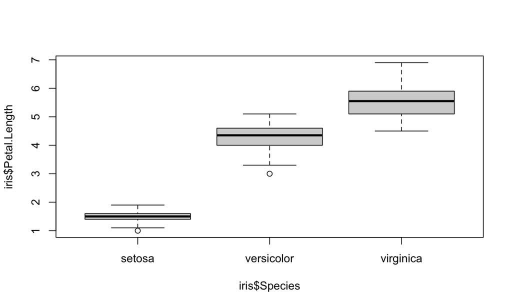

```r
#un boxplot
boxplot(formula=iris$Petal.Length~iris$Species)
```

## **Bases de Datos(IV)** <sub>*(DF, data frame)*</sub>

Estadísticas Básicas

```r
#Extraer solo información de una especie
setosa<-iris[which(iris$Species=="setosa"),]
#Correlación entre 'length' y 'width'
cor.test(x=setosa$Sepal.Length, y=setosa$Sepal.Width)
```

```
##
##  Pearson's product-moment correlation
##
## data:  setosa$Sepal.Length and setosa$Sepal.Width
## t = 7.6807, df = 48, p-value = 6.71e-10
## alternative hypothesis: true correlation is not equal to 0
## 95 percent confidence interval:
##  0.5851391 0.8460314
## sample estimates:
##       cor
## 0.7425467
```

## **Visualización de Datos** <sub>*(Plotting)*</sub>

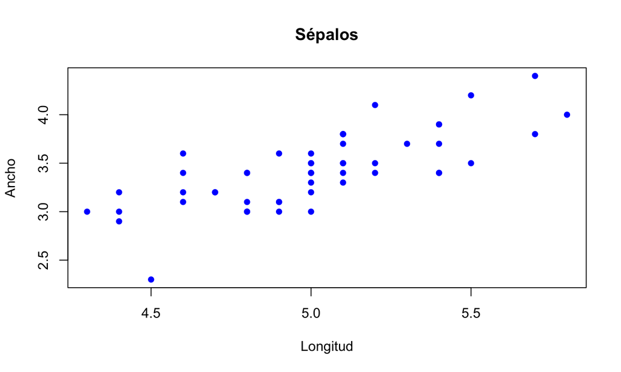

```r
#Plot orrelación entre 'length' y 'width'
plot(x=setosa$Sepal.Length, y=setosa$Sepal.Width, main="Sépalos",
     xlab="Longitud", ylab="Ancho", pch=16, cex=1, col="blue")
```

## **Visualización de Datos(II)** <sub>*(Plotting)*</sub>

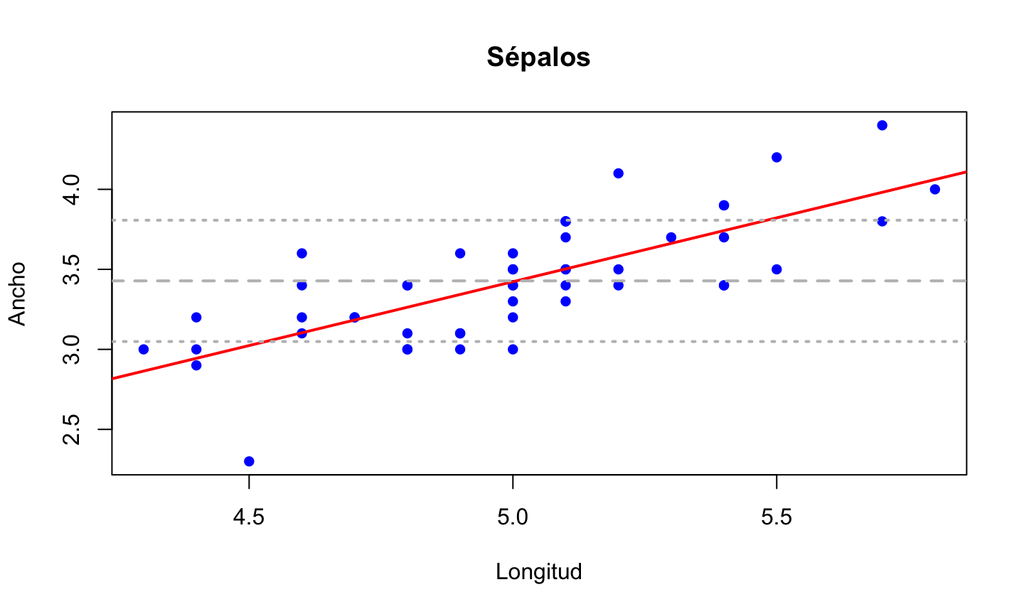

```r
plot(x=setosa$Sepal.Length, y=setosa$Sepal.Width, main="Sépalos", xlab="Longitud", ylab="Ancho", pch=16, cex=1, col="blue")
abline(reg=lm(setosa$Sepal.Width~setosa$Sepal.Length), col="red", lwd=2)
abline(h=mean(setosa$Sepal.Width), col="grey", lwd=2, lty=2)
abline(h=mean(setosa$Sepal.Width) + sd(setosa$Sepal.Width), col="grey",
  lwd=2, lty=3)
abline(h=mean(setosa$Sepal.Width) - sd(setosa$Sepal.Width), col="grey",
lwd=2, lty=3)
```